# Hotel Booking EDA

### Hotel Booking

The hospitality industry generates most revenue through the customers visiting their hotels or restaurants by booking rooms, holiday packages, events, and many other activities. Due to increased stress levels in both professional and personal life, people plan to go out and spend with their families or friends or go close to nature. This is the main advantage to the hospitality industry to catch the opportunity and make customers visit their hotels by attracting them with their hospitality.

DATA SET LINK: https://www.kaggle.com/mojtaba142/hotel-booking

This dataset contains 119390 observations for a City Hotel and a Resort Hotel. Each observation represents a hotel booking between the 1st of July 2015 and 31st of August 2017, including booking that effectively arrived and booking that were canceled.

hotel - The datasets contains the booking information of two hotel. One of the hotels is a resort hotel and the other is a city hotel.

is_canceled - Value indicating if the booking was canceled (1) or not (0).

lead_time - Number of days that elapsed between the entering date of the booking into the PMS and the arrival date.

arrival_date_year - Year of arrival date.

arrival_date_month - Month of arrival date with 12 categories: “January” to “December”

arrival_date_week_number - Week number of the arrival date

arrival_date_day_of_month - Day of the month of the arrival date

stays_in_weekend_nights - Number of weekend nights (Saturday or Sunday) the guest stayed or booked to stay at the hotel

stays_in_week_nights - Number of week nights (Monday to Friday) the guest stayed or booked to stay at the hotel BO and BL/Calculated by counting the number of week nights.

adults - Number of adults

children - Number of children

babies - Number of babies

meal - BB – Bed & Breakfast

country - Country of origin.

market_segment - Market segment designation.

TA - Travel Agents TO - Tour Operators distribution_channel - Booking distribution channel. The term “TA” means “Travel Agents” and “TO” means “Tour Operators”

is_repeated_guest - Value indicating if the booking name was from a repeated guest (1) or not (0)

previous_cancellations - Number of previous bookings that were cancelled by the customer prior to the current booking

previous_bookings_not_canceled - Number of previous bookings not cancelled by the customer prior to the current booking

reserved_room_type - Code of room type reserved. Code is presented instead of designation for anonymity reasons

assigned_room_type - Code for the type of room assigned to the booking. Sometimes the assigned room type differs from the reserved room type due to hotel operation reasons (e.g. overbooking) or by customer request. Code is presented instead of designation for anonymity reasons

booking_changes - Number of changes/amendments made to the booking from the moment the booking was entered on the PMS until the moment of check-in or cancellation

deposit_type

No Deposit – no deposit was made; Non Refund – a deposit was made in the value of the total stay cost; Refundable – a deposit was made with a value under the total cost of stay. agent - ID of the travel agency that made the booking

company - ID of the company/entity that made the booking or responsible for paying the booking. ID is presented instead of designation for anonymity reasons

days_in_waiting_list - Number of days the booking was in the waiting list before it was confirmed to the customer

customer_type

Group – when the booking is associated to a group; Transient – when the booking is not part of a group or contract, and is not associated to other transient booking; Transient-party – when the booking is transient, but is associated to at least other transient booking adr - Average Daily Rate (Calculated by dividing the sum of all lodging transactions by the total number of staying nights)

required_car_parking_spaces - Number of car parking spaces required by the customer

total_of_special_requests - Number of special requests made by the customer (e.g. twin bed or high floor)

reservation_status

Check-Out – customer has checked in but already departed; No-Show – customer did not check-in and did inform the hotel of the reason why reservation_status_date - Date at which the last status was set. This variable can be used in conjunction with the ReservationStatus to understand when was the booking canceled or when did the customer checked-out of the hotel

### Problem Statement

The hospitality industry’s problem is understanding the customer behavior in selecting the holiday plan and identifying the period that the majority of the customers plan to go for holidays so that the management prepares themselves to meet the demand and satisfy the customer.

### Objectives

My primary objective are:

To clean the data set by imputing the missing value with an appropriate value

To understand the relation between the variables such that we can identify the interdependency of the variables

My secondary objectives are:

To identify the time or month in the year where most customers plan for the holidays.

To find out the type of hotel that has more customer base in the market

To understand the customer satisfaction level with the help of the visiting frequency rate.

To analyze the year which has generated the more customer visit to the hotels

To understand which hotel has undergone more cancellations by the customers

To analyze the type of customers visiting the hotels like only the couples or the family

```python
import pandas as pd
import numpy as np
import seaborn as sns
import matplotlib.pyplot as plt
pd.pandas.set_option("display.max_columns",None)
```

```python
df=pd.read_csv("hotel_bookings.csv")
```

```python
df.shape
```

```
(119390, 32)
```

```python
df.head()
```

|  | hotel | is_canceled | lead_time | arrival_date_year | arrival_date_month | arrival_date_week_number | arrival_date_day_of_month | stays_in_weekend_nights | stays_in_week_nights | adults | children | babies | meal | country | market_segment | distribution_channel | is_repeated_guest | previous_cancellations | previous_bookings_not_canceled | reserved_room_type | assigned_room_type | booking_changes | deposit_type | agent | company | days_in_waiting_list | customer_type | adr | required_car_parking_spaces | … |
| --- | --- | --- | --- | --- | --- | --- | --- | --- | --- | --- | --- | --- | --- | --- | --- | --- | --- | --- | --- | --- | --- | --- | --- | --- | --- | --- | --- | --- | --- | --- |
| 0 | Resort Hotel | 0 | 342 | 2015 | July | 27 | 1 | 0 | 0 | 2 | 0.0 | 0 | BB | PRT | Direct | Direct | 0 | 0 | 0 | C | C | 3 | No Deposit | NaN | NaN | 0 | Transient | 0.0 | 0 | … |
| 1 | Resort Hotel | 0 | 737 | 2015 | July | 27 | 1 | 0 | 0 | 2 | 0.0 | 0 | BB | PRT | Direct | Direct | 0 | 0 | 0 | C | C | 4 | No Deposit | NaN | NaN | 0 | Transient | 0.0 | 0 | … |
| 2 | Resort Hotel | 0 | 7 | 2015 | July | 27 | 1 | 0 | 1 | 1 | 0.0 | 0 | BB | GBR | Direct | Direct | 0 | 0 | 0 | A | C | 0 | No Deposit | NaN | NaN | 0 | Transient | 75.0 | 0 | … |
| 3 | Resort Hotel | 0 | 13 | 2015 | July | 27 | 1 | 0 | 1 | 1 | 0.0 | 0 | BB | GBR | Corporate | Corporate | 0 | 0 | 0 | A | A | 0 | No Deposit | 304.0 | NaN | 0 | Transient | 75.0 | 0 | … |
| 4 | Resort Hotel | 0 | 14 | 2015 | July | 27 | 1 | 0 | 2 | 2 | 0.0 | 0 | BB | GBR | Online TA | TA/TO | 0 | 0 | 0 | A | A | 0 | No Deposit | 240.0 | NaN | 0 | Transient | 98.0 | 0 | … |

### Missing Values

```python
Feature_nan= [features for features in df.columns if df[features].isnull().sum()>1]
for feature in Feature_nan:
    n= df[feature].isnull().sum()
    n=np.round((n/119390)*100,3)
    print(feature, n)
```

```
children 0.003
country 0.409
agent 13.686
company 94.307
```

The data contains some missing values in childern, country, agent, company variables. The company has 94.307%, children has 0.003%, agent has 13.686, country has 0.409% of missing observations

```python
Median_value= df['children'].median()
df['children'].fillna(Median_value,inplace=True)
```

The children variable has 0.003% of missing data which is very less compared with the whole data set. Imputation of the data will be posible and it doesn't effect the output. So, I have selected median value to impute the missing observation as it doesnt have any influence by the outliers of the data

```python
df.drop(['company'],axis='columns', inplace=True)
```

The company has 94.307% which is very high and also cannot impute with just 6% of available data. So, I am deleting the whole variable

```python
df.country.mode()
df.country.fillna('PRT', inplace= True)
```

The country has 0.409% of the missing the observations. The data is categorical I have selected mode to impute the missing observations

```python
df.dropna(inplace=True)
```

The agent variable is the ID of the agents Which is unique in nature. So the ID cannot be imputed with any values of the varibles. So I am dropping all the remaining null values which were under the agent variable

```python
df.isnull().sum()
```

```
hotel                             0
is_canceled                       0
lead_time                         0
arrival_date_year                 0
arrival_date_month                0
arrival_date_week_number          0
arrival_date_day_of_month         0
stays_in_weekend_nights           0
stays_in_week_nights              0
adults                            0
children                          0
babies                            0
meal                              0
country                           0
market_segment                    0
distribution_channel              0
is_repeated_guest                 0
previous_cancellations            0
previous_bookings_not_canceled    0
reserved_room_type                0
assigned_room_type                0
booking_changes                   0
deposit_type                      0
agent                             0
days_in_waiting_list              0
customer_type                     0
adr                               0
required_car_parking_spaces       0
total_of_special_requests         0
reservation_status                0
reservation_status_date           0
dtype: int64
```

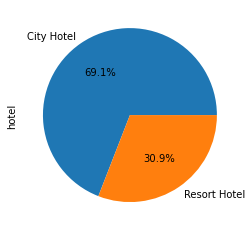

```python
df['hotel'].value_counts().plot.pie(autopct='%1.1f%%',explode=(0,0))
```

The data contains two types of hotels: a resort hotel and a city hotel. The above pie chart was drawn to find out which hotel has more customer bookings. This visualization says that the city resort has more bookings compared with the resort hotel.

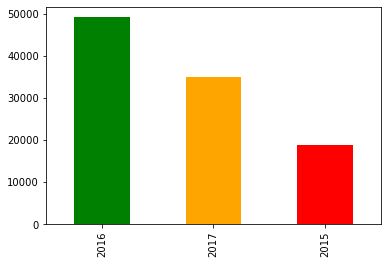

```python
df['arrival_date_year'].value_counts().plot.bar(color= ['green','orange','red'])
```

The data contains three years of data 2015-2017. Here I have analyzed the hotel bookings by the customers in three years which results in the high bookings in the 2016 year when compared with remaining years.

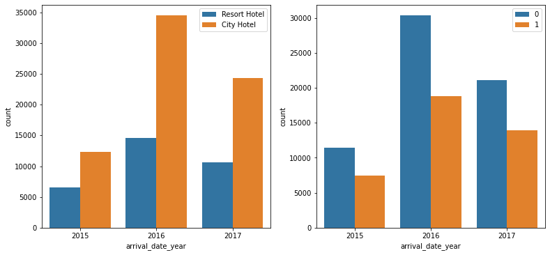

```python
plt.figure(figsize=(20,20))
plt.subplot(3,3,1)
sns.countplot(data=df , x="arrival_date_year" , hue="hotel" )
plt.legend()
plt.subplot(3,3,2)
sns.countplot(data=df , x="arrival_date_year" , hue="is_canceled" )
plt.legend()
```

The data contains three years of data 2015-2017. Here I have analyzed the hotel bookings by the customers in three years which results in the high bookings in the 2016 year in both the hotels when compared with years and city hotel has high bookings comparatively in all three years. The second graphs explains us about the cancellation of bookings by the customers. In 2016 the hotels has maximum number of cancellations

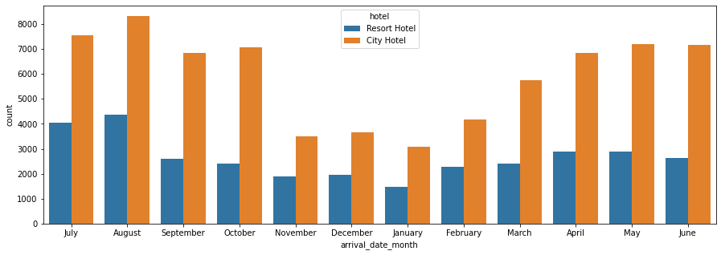

```python
plt.figure(figsize=(15,5))
sns.countplot(data=df , x="arrival_date_month", hue="hotel" )
```

```python
countries = df.value_counts(subset=['hotel','country']).reset_index(name='count')
countries
```

|  | hotel | country | count |
| --- | --- | --- | --- |
| 0 | City Hotel | PRT | 25324 |
| 1 | Resort Hotel | PRT | 12423 |
| 2 | City Hotel | FRA | 8364 |
| 3 | City Hotel | DEU | 5898 |
| 4 | Resort Hotel | GBR | 5699 |
| ... | ... | ... | ... |
| 281 | City Hotel | DMA | 1 |
| 282 | Resort Hotel | BDI | 1 |
| 283 | Resort Hotel | BHR | 1 |
| 284 | Resort Hotel | BHS | 1 |
| 285 | Resort Hotel | BWA | 1 |

286 rows × 3 columns

```python
bar = countries.nlargest(6, 'count')
bar
```

|  | hotel | country | count |
| --- | --- | --- | --- |
| 0 | City Hotel | PRT | 25324 |
| 1 | Resort Hotel | PRT | 12423 |
| 2 | City Hotel | FRA | 8364 |
| 3 | City Hotel | DEU | 5898 |
| 4 | Resort Hotel | GBR | 5699 |
| 5 | City Hotel | GBR | 5190 |

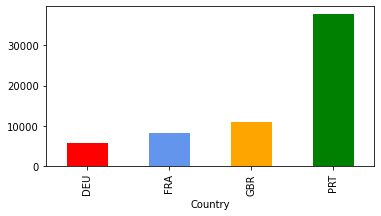

```python
plt.figure(figsize=(20,10))
plt.subplot(3,3,1)
bar.groupby('country')['count'].sum().plot.bar(color= ['red','cornflowerblue','orange','green'])
plt.xlabel('Country')
```

It is very important for the hotel industry to find out the customer's from where they belongs to. This help hotel to understand the customer's attitude, their needs and helps the management to improve their services. This also helps the industry to know their customer base and also the market status in different geographical locations. This helps them further to improve their marketing strategies. From the chart we can easily understand the top four countries from where the customers are visiting their hotels. Portugal stands at first position where majority of the customers are from Portugal, follwed by Great Britain, France, Germany.

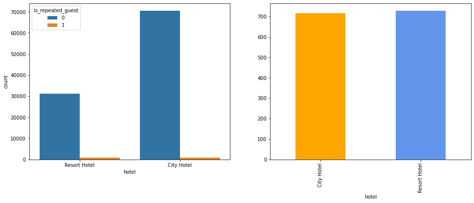

```python
plt.figure(figsize=(25,20))
plt.subplot(3,3,1)
sns.countplot(data=df , x="hotel" , hue="is_repeated_guest" )
plt.subplot(3,3,2)
df.groupby('hotel')['is_repeated_guest'].sum().plot.bar(color= ['orange','cornflowerblue'])
```

The above charts explains about the repeated customers to the hotels. The percent of repeated customers are low in both type of hotels. The first chart tells explains that the city hotel has more customers than the resort hotel. However when it comes the repeated customers the resort hotel has more compared to the city hotel. This is clearly explained in the second graph. Though the differnce is less but when we compared with the total bookings the percent of repeated customers will have an impact on the hotels.

```python
df['Dependents']= df['children']+ df['babies']
```

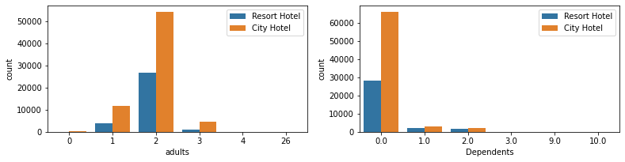

```python
plt.figure(figsize=(20,10))
plt.subplot(3,3,1)
sns.countplot(data=df , x="adults" , hue="hotel" )
plt.legend(loc='upper right')
plt.subplot(3,3,2)
sns.countplot(data=df , x="Dependents" , hue="hotel")
plt.legend(loc='upper right')
```

The data contains the details of the customer booking the hotels. It contains the adults and the children in the booking details. This means families, newly married couples and the possibility of friends. So, if we analyze the graph, we can say that the customers are more of newly married couples and friends.

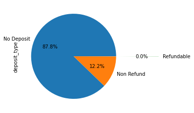

```python
df['deposit_type'].value_counts().plot.pie(autopct='%1.1f%%',explode=(0,0,1))
```

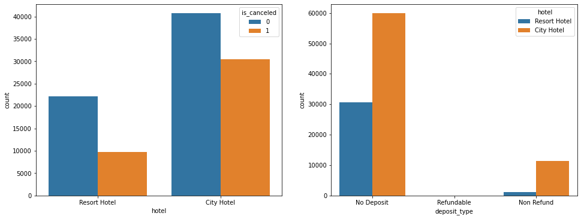

```python
plt.figure(figsize=(25,20))
plt.subplot(3,3,1)
sns.countplot(data=df , x="hotel" , hue="is_canceled" )
plt.subplot(3,3,2)
sns.countplot(data=df , x="deposit_type" , hue="hotel" )
```

### Recommendations

The development in the technology can help the hotel industry improve its customer base by adopting chatbots, building attractive websites, especially the virtual reality technology which make the customers get to experience the feeling of being inside before the visit.

Today’s world is all about digital transformation. Due to the development in the standards of living and education levels of the people, the customers are willing to pay more to experience the new things. So, the hotel industry has to transform from traditional practices to digital.

Seasons is also one of the significant factors which affect the hotel industry. Especially the resort’s revenue varies concerning the seasons. So, based on the seasons, the management has to develop innovative ideas to attract the customer. The resorts function at some specific locations where nature gets its beauty based on the seasons. To attract visitors, management must maintain some cross-functional activities.

The customer satisfaction is the prime factor for the successful running of the hotel industry. So, the management has to train their employees well enough to maintain the healthy relationship with the customers

### Conclusion

The hotel business is one of the old businesses that has now become a prominent business globally. The hotels get their differentiation based on their innovative outcomes to attract customers. Customers are looking for simple technologies that can function at their fingertips through mobile phones in the current era. Many hotels are implementing AI technology in building their websites which makes the customers feel a new experience. Although the initial investment is huge, the adoption of technology helps the hotel industry’s long-term revenue generation.